# Instrumental Variables — Simultaneity, IV Estimators, and LATE

Huan Deng

October 31, 2025

This single R Markdown file aligns with the lecture slides on **Simultaneity & Selection** (pp. 8–9), **IV Estimator & TSLS** (pp. 12–17), and **LATE & Assumptions** (pp. 23–38).

> **How to use**: Knit top‑to‑bottom, or run each section independently. The setup chunk installs needed packages if missing.

## 0.1 0) Setup and common libraries

```r
knitr::opts_chunk$set(fig.width=7, fig.height=4.6, dpi=120)
pkgs <- c("AER","MASS","sandwich","lmtest","ggplot2","dplyr","broom")
for (p in pkgs) if (!requireNamespace(p, quietly = TRUE)) {
  install.packages(p, repos = "https://cloud.r-project.org")
}
suppressPackageStartupMessages({
  library(AER)        # ivreg (2SLS)
  library(MASS)       # mvrnorm (simulation)
  library(sandwich)   # vcovHC for robust SEs
  library(lmtest)     # coeftest
  library(ggplot2)    # plots
  library(dplyr)      # data wrangling
  library(broom)      # tidy summaries
})
set.seed(1)
theme_set(theme_minimal(base_size = 13))
```

# 1 PART I — Simultaneity & Selection (Motivation for IV)

> **Slides:** Simultaneous equations (p. 8), selection (p. 9). The goal is to see **why OLS fails** and **what an instrument fixes**.

## 1.1 1) Simultaneity: supply & demand → endogenous price

**Idea.** Equilibrium price `P` depends on *both* demand and supply shocks. Regressing `Q` on `P`—even with a single shifter control—**does not** identify either curve’s slope. With a **demand shifter** `Zd`, you can IV‑identify **supply**; with a **supply shifter** `Zs`, you can IV‑identify **demand**.

```r
# Structural parameters
n  <- 5000
a1 <- 0; b1 <- -0.8; t1 <- 1.0  # demand: Qd = a1 + b1*P + t1*Zd + u1  (b1 < 0)
a2 <- 0; b2 <-  0.6; t2 <- 1.0  # supply: Qs = a2 + b2*P + t2*Zs + u2  (b2 > 0)

Zd <- rnorm(n)                  # demand shifter (e.g., income)
Zs <- rnorm(n)                  # supply shifter (e.g., cost)
u1 <- rnorm(n)                  # demand shock
u2 <- rnorm(n)                  # supply shock

# Market equilibrium: solve Qd = Qs for P, then compute Q (slides p. 8)
P <- (a2 - a1 + t2*Zs - t1*Zd + u2 - u1) / (b1 - b2)   # <-- endogenous in u1 & u2
Q <- a1 + b1*P + t1*Zd + u1                            # realized quantity at equilibrium

dat <- data.frame(Q, P, Zd, Zs, u1, u2)
```

**Why OLS is biased** (endogeneity check):

```r
c(cor_P_u1 = cor(dat$P, dat$u1),   # corr(P, demand shock)   <-- nonzero
  cor_P_u2 = cor(dat$P, dat$u2))   # corr(P, supply shock)   <-- nonzero
```

```
##   cor_P_u1   cor_P_u2
##  0.4956975 -0.4945619
```

### 1.1.1 1A) Two OLS with shifter controls (still wrong)

> Even after controlling for a shifter, `P` remains endogenous—so the slope on `P` is **not** the structural slope.

```r
ols_demand_like <- lm(Q ~ P + Zd, data = dat)  # includes demand shifter
ols_supply_like <- lm(Q ~ P + Zs, data = dat)  # includes supply shifter
rbind(
  `True demand slope b1` = b1,
  `OLS slope on P in Q~P+Zd` = coef(ols_demand_like)["P"],
  `True supply slope  b2` = b2,
  `OLS slope on P in Q~P+Zs` = coef(ols_supply_like)["P"]
)
```

```
##                                   P
## True demand slope b1     -0.8000000
## OLS slope on P in Q~P+Zd -0.3427673
## True supply slope  b2     0.6000000
## OLS slope on P in Q~P+Zs  0.1409920
```

**Why bias persists:** The partial correlation between `P` and the relevant structural error remains non‑zero even after partialling out the shifter.

```r
# Partial corr of P with demand error u1, given Zd
p_resid_d <- resid(lm(P ~ Zd, data = dat))
c(partial_cor_Pu1_given_Zd = cor(p_resid_d, dat$u1))    # <-- still nonzero
```

```
## partial_cor_Pu1_given_Zd
##                0.5691283
```

```r
# Partial corr of P with supply error u2, given Zs
p_resid_s <- resid(lm(P ~ Zs, data = dat))
c(partial_cor_Pu2_given_Zs = cor(p_resid_s, dat$u2))    # <-- still nonzero
```

```
## partial_cor_Pu2_given_Zs
##               -0.5742471
```

### 1.1.2 1B) Use IV with the **opposite** shifter to identify each curve

```r
# Identify demand: instrument P with Zs, include Zd as a control (belongs in demand)
iv_demand <- ivreg(Q ~ P + Zd | Zs + Zd, data = dat)   # <-- key IV spec for demand
# Identify supply: instrument P with Zd, include Zs as a control (belongs in supply)
iv_supply <- ivreg(Q ~ P + Zs | Zd + Zs, data = dat)   # <-- key IV spec for supply

list(
  demand_true_b1 = b1,
  demand_IV_b1   = coef(summary(iv_demand))["P","Estimate"],
  supply_true_b2 = b2,
  supply_IV_b2   = coef(summary(iv_supply))["P","Estimate"]
)
```

```
## $demand_true_b1
## [1] -0.8
##
## $demand_IV_b1
## [1] -0.8061099
##
## $supply_true_b2
## [1] 0.6
##
## $supply_IV_b2
## [1] 0.5884424
```

> **Diagnostic tip (p. 17):** Check `summary(..., diagnostics=TRUE)` for first‑stage F, Wu–Hausman, and Sargan (over‑ID when applicable).

```r
summary(iv_demand, diagnostics = TRUE)
summary(iv_supply, diagnostics = TRUE)
```

[output not shown]

## 1.2 2) Selection: college attendance & wages

**Idea.** Ability `A` drives both college attendance `D` and wages `Y`, creating **positive selection**. OLS on `D` is biased; controlling for `A` or using a valid instrument `Z` recovers the causal effect.

```r
set.seed(2)
n   <- 10000
A   <- rnorm(n)             # unobserved ability (drives D and Y)
Z   <- rbinom(n, 1, 0.5)    # instrument (e.g., proximity/scholarship)
nu  <- rnorm(n)             # choice shock
eps <- rnorm(n)             # wage shock

# College choice: D* = g0 + g1*Z + gA*A + nu; D = 1{D* > 0}
g0 <- -0.2; g1 <- 0.8; gA <- 1.0
Dstar <- g0 + g1*Z + gA*A + nu
D     <- as.numeric(Dstar > 0)

# Wage equation: Y = beta*D + tau*A + eps
beta <- 0.0   # set to zero to highlight pure selection bias
tau  <- 1.0
Y    <- beta*D + tau*A + eps
dd   <- data.frame(Y, D, A, Z)
```

```r
cat("cor(D, A) =", round(cor(dd$D, dd$A), 3), "\n")   # <-- selection present
```

```
## cor(D, A) = 0.529
```

```r
summary(lm(Y ~ D, data = dd))$coef                    # OLS (biased)
```

```
##               Estimate Std. Error   t value      Pr(>|t|)
## (Intercept) -0.5994391 0.01945228 -30.81588 2.749115e-199
## D            1.0772430 0.02615111  41.19301  0.000000e+00
```

```r
summary(lm(Y ~ D + A, data = dd))$coef["D",, drop=FALSE]  # OLS controlling for A (unbiased if A observed)
```

```
##     Estimate Std. Error  t value   Pr(>|t|)
## D 0.04438824 0.02382939 1.862752 0.06252654
```

```r
fit_iv <- ivreg(Y ~ D | Z, data = dd)                 # IV using Z for D
c(true_beta = beta, iv_beta = coef(summary(fit_iv))["D","Estimate"])
```

```
##  true_beta    iv_beta
##  0.0000000 -0.1454939
```

```r
summary(fit_iv, diagnostics = TRUE)$diagnostics       # first stage, weak-IV checks
```

```
##                  df1  df2 statistic       p-value
## Weak instruments   1 9998  515.1999 2.943700e-111
## Wu-Hausman         1 9997  113.9268  1.876491e-26
## Sargan             0   NA        NA            NA
```

> **Takeaway:** Endogeneity from simultaneity or self‑selection **biases OLS**. Valid instruments address the bias by purging endogenous variation in `D`. (Slides pp. 8–9, 12–17.)

# 2 PART II — IV Estimators (Wald, Reduced‑Form, TSLS) with Plots

> **Slides:** IV estimator derivations and TSLS (pp. 12–17). We visualize the reduced forms and “project‑then‑regress” intuition.

## 2.1 3) Just‑identified IV (binary Z) — Wald and reduced‑form ratio

```r
n <- 4000
rho <- 0.6
Sigma <- matrix(c(1, rho, rho, 1), 2, 2)
eu <- MASS::mvrnorm(n, mu = c(0,0), Sigma = Sigma)
eps <- eu[,1]; u <- eu[,2]
Z   <- rbinom(n, 1, 0.5)   # instrument
pi  <- 0.7                 # first-stage strength
beta_true <- 1.0
D <- pi*Z + u
Y <- 1 + beta_true*D + eps
dat_iv <- data.frame(Y,D,Z)
```

```r
# Wald = Cov(Y,Z)/Cov(D,Z) = slope(Y~Z) / slope(D~Z)  <-- slides Eq. (8)–(9)
wald <- cov(dat_iv$Y, dat_iv$Z) / cov(dat_iv$D, dat_iv$Z)
rfY  <- lm(Y ~ Z, data = dat_iv)
rfD  <- lm(D ~ Z, data = dat_iv)
rf_ratio <- coef(rfY)["Z"] / coef(rfD)["Z"]            # reduced-form ratio
fit_iv <- ivreg(Y ~ D | Z, data = dat_iv)              # TSLS equals Wald here
rbind(true_beta = beta_true, wald, reduced_form_ratio = rf_ratio, iv_tsls = coef(fit_iv)["D"])
```

```
##                            Z
## true_beta          1.0000000
## wald               0.9408467
## reduced_form_ratio 0.9408467
## iv_tsls            0.9408467
```

**Plots:** (i) naive `Y~D` vs (ii) `Y~D̂` (first‑stage fitted).

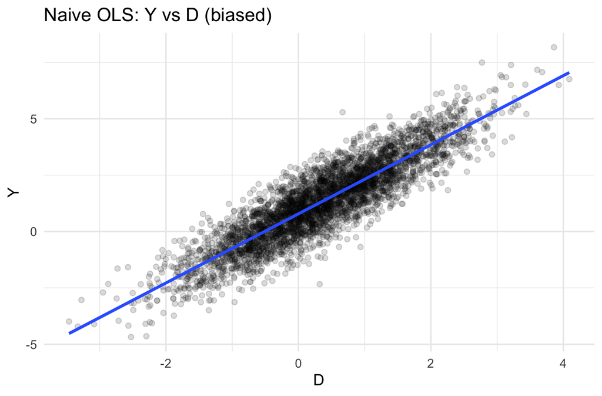

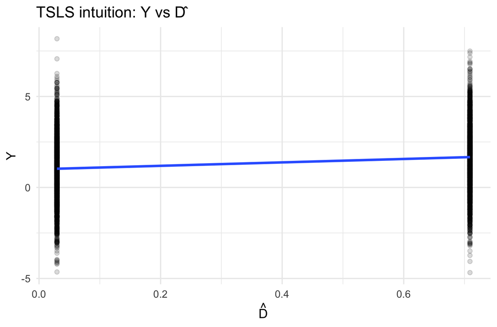

```r
fs <- lm(D ~ Z, data = dat_iv); dat_iv$Dhat <- fitted(fs)  # <-- first stage
p1 <- ggplot(dat_iv, aes(D, Y)) +
  geom_point(alpha=.15) + geom_smooth(method="lm", se=FALSE) +
  labs(title="Naive OLS: Y vs D (biased)", x="D", y="Y")
p2 <- ggplot(dat_iv, aes(Dhat, Y)) +
  geom_point(alpha=.15) + geom_smooth(method="lm", se=FALSE) +
  labs(title="TSLS intuition: Y vs D̂", x=expression(hat(D)), y="Y")
p1; p2
```

**Plots:** Reduced forms (means by Z).

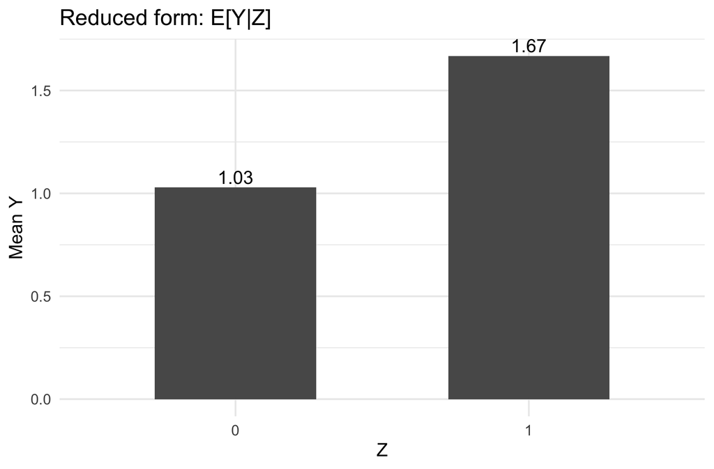

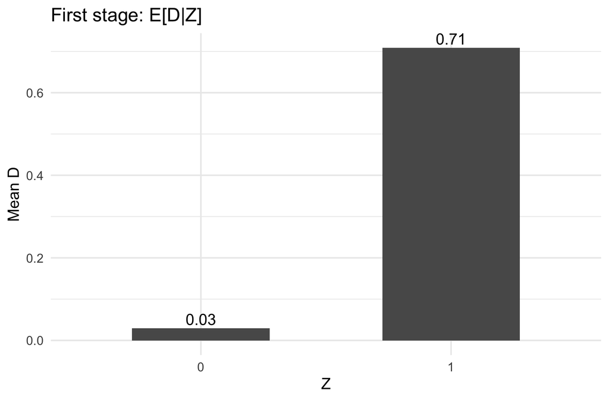

```r
means <- dat_iv %>% group_by(Z) %>% summarise(Ybar=mean(Y), Dbar=mean(D))
pY <- ggplot(means, aes(factor(Z), Ybar)) +
  geom_col(width=.55) + geom_text(aes(label=round(Ybar,2)), vjust=-0.3) +
  labs(title="Reduced form: E[Y|Z]", x="Z", y="Mean Y")
pD <- ggplot(means, aes(factor(Z), Dbar)) +
  geom_col(width=.55) + geom_text(aes(label=round(Dbar,2)), vjust=-0.3) +
  labs(title="First stage: E[D|Z]", x="Z", y="Mean D")
pY; pD
```

## 2.2 4) Over‑identified IV (two instruments) + diagnostics

```r
Z2 <- rbinom(n, 1, 0.5)
D2 <- 0.6*Z + 0.5*Z2 + u
Y2 <- 1 + beta_true*D2 + eps
dat2 <- data.frame(Y=Y2, D=D2, Z1=Z, Z2=Z2)
fit_over <- ivreg(Y ~ D | Z1 + Z2, data = dat2)
summary(fit_over)$coef["D",, drop=FALSE]
```

```
##    Estimate Std. Error  t value     Pr(>|t|)
## D 0.9271158 0.04438929 20.88603 4.993935e-92
```

```r
summary(fit_over, diagnostics = TRUE)$diagnostics   # <-- first-stage F, Wu–Hausman, Sargan (homo)
```

```
##                  df1  df2    statistic       p-value
## Weak instruments   2 3997 278.50175379 5.842030e-114
## Wu-Hausman         1 3997 345.45406652  5.026924e-74
## Sargan             1   NA   0.00576895  9.394560e-01
```

**First‑stage components (visual):**

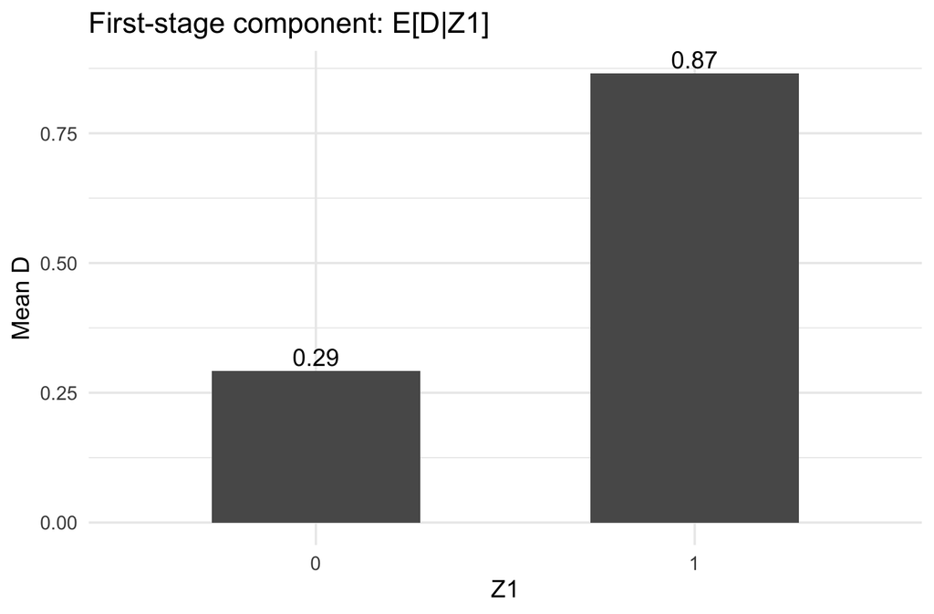

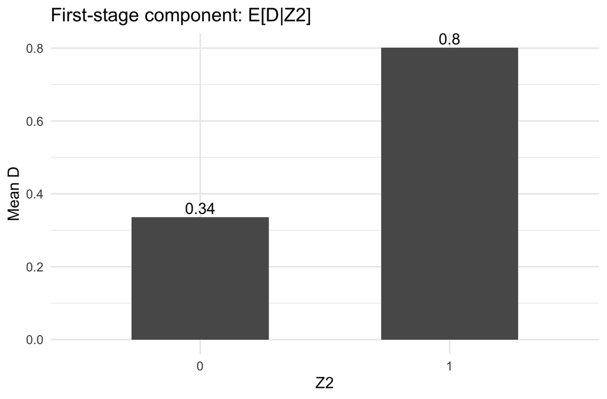

```r
means_Z1 <- dat2 %>% group_by(Z1) %>% summarise(Dbar=mean(D))
means_Z2 <- dat2 %>% group_by(Z2) %>% summarise(Dbar=mean(D))
pZ1 <- ggplot(means_Z1, aes(factor(Z1), Dbar)) +
  geom_col(width=.55) + geom_text(aes(label=round(Dbar,2)), vjust=-0.3) +
  labs(title="First-stage component: E[D|Z1]", x="Z1", y="Mean D")
pZ2 <- ggplot(means_Z2, aes(factor(Z2), Dbar)) +
  geom_col(width=.55) + geom_text(aes(label=round(Dbar,2)), vjust=-0.3) +
  labs(title="First-stage component: E[D|Z2]", x="Z2", y="Mean D")
pZ1; pZ2
```

> **Note:** `summary(..., diagnostics=TRUE)` reports Sargan under homoskedasticity. For robust over‑ID tests, use GMM variants; for robust/clustered SEs, pair `ivreg` with `sandwich::vcovHC`/`vcovCL`.

# 3 PART III — LATE & Assumptions (Potential Outcomes + Visuals)

> **Slides:** LATE derivation & assumptions (pp. 23–27) and discussions (pp. 31–38). We simulate principal strata and then **violate assumptions one at a time**.

## 3.1 5) Simulator with toggles (relevance, exogeneity, exclusion, monotonicity)

```r
inv_logit <- function(x) 1/(1+exp(-x))

simulate_late <- function(n = 20000,
                          p_c = 0.3, p_a = 0.2, p_n = NULL, p_d = 0.0,
                          tau_c = 2.0, tau_a = 0.0, tau_n = 0.0,
                          tau_sd = 0.4,           # heterogeneity around means
                          exclusion = 0.0,        # direct Z->Y effect (violates exclusion if != 0)
                          exog_k = 0.0,           # if > 0, Z depends on ability (violates exogeneity)
                          alpha_A = 1.0,          # ability effect on Y0
                          seed = 11) {
  if (is.null(p_n)) p_n <- 1 - p_c - p_a - p_d      # <-- auto-balance shares
  if (any(c(p_c, p_a, p_n, p_d) < 0)) stop("Strata shares must be nonnegative.")
  if (abs(p_c + p_a + p_n + p_d - 1) > 1e-8) stop("Strata shares must sum to 1.")
  set.seed(seed)

  A <- rnorm(n)                                     # latent trait
  # Instrument Z: exogenous if exog_k == 0; else P(Z=1) increases with A
  if (exog_k == 0) {
    Z <- rbinom(n, 1, 0.5)
  } else {
    pz <- inv_logit(exog_k * A)                     # <-- exogeneity violation knob
    Z  <- rbinom(n, 1, pz)
  }

  G <- sample(c("C","A","N","D"), size=n, replace=TRUE, prob=c(p_c, p_a, p_n, p_d))
  D0 <- as.numeric(G %in% c("A","D"))
  D1 <- as.numeric(G %in% c("A","C"))
  D  <- ifelse(Z==1, D1, D0)                        # realized treatment

  U  <- rnorm(n)
  Y0 <- alpha_A * A + U
  tau_bar <- ifelse(G=="C", tau_c, ifelse(G=="A", tau_a, tau_n))
  tau_i <- tau_bar + rnorm(n, 0, tau_sd)
  Y1 <- Y0 + tau_i

  Y  <- ifelse(D==1, Y1, Y0) + exclusion * Z        # <-- exclusion violation knob

  data.frame(Y, D, Z, G, Y0, Y1, tau_i, D0, D1, A,
             p_c=p_c, p_a=p_a, p_n=p_n, p_d=p_d, exclusion=exclusion, exog_k=exog_k)
}

summarise_late <- function(dat) {
  ITT_y <- with(dat, mean(Y[Z==1]) - mean(Y[Z==0]))
  ITT_d <- with(dat, mean(D[Z==1]) - mean(D[Z==0]))
  Wald  <- ITT_y / ITT_d                                 # <-- LATE under assumptions
  True_CATE <- with(dat, mean(Y1[G=="C"] - Y0[G=="C"]))
  fit_iv <- ivreg(Y ~ D | Z, data = dat)
  fs     <- lm(D ~ Z, data = dat)
  F1     <- tryCatch(summary(fs)$fstatistic[1], error=function(e) NA_real_)
  data.frame(ITT_y=ITT_y, ITT_d=ITT_d, Wald=Wald,
             True_Complier_ATE=True_CATE,
             IV_beta=coef(fit_iv)["D"],
             IV_se_HC1=sqrt(diag(vcovHC(fit_iv, type="HC1"))["D"]),
             FirstStage_F=as.numeric(F1))
}

plot_stage <- function(dat, title_suffix="") {
  means <- dat %>% group_by(Z) %>% summarise(Dbar=mean(D), Ybar=mean(Y))
  pD <- ggplot(means, aes(factor(Z), Dbar)) +
    geom_col(width=.55) + geom_text(aes(label=sprintf("%.3f", Dbar)), vjust=-0.3) +
    labs(title=paste0("First stage: E[D|Z] ", title_suffix), x="Z", y="Mean D")
  pY <- ggplot(means, aes(factor(Z), Ybar)) +
    geom_col(width=.55) + geom_text(aes(label=sprintf("%.3f", Ybar)), vjust=-0.3) +
    labs(title=paste0("Reduced form: E[Y|Z] ", title_suffix), x="Z", y="Mean Y")
  list(pD=pD, pY=pY)
}

plot_tau <- function(dat, title="Complier treatment effects (τ)") {
  cate <- with(dat, mean(Y1[G=="C"] - Y0[G=="C"]))     # dashed line
  ITTy <- with(dat, mean(Y[Z==1]) - mean(Y[Z==0]))
  ITTd <- with(dat, mean(D[Z==1]) - mean(D[Z==0]))
  ggplot(dat %>% filter(G=="C"), aes(tau_i)) +
    geom_histogram(bins=30) +
    geom_vline(xintercept=cate, linetype=2) +
    geom_vline(xintercept=ITTy/ITTd, linetype=3) +
    labs(title=title, subtitle="Dashed = true complier ATE; dotted = Wald ratio",
         x=expression(tau[i]), y="Count")
}
```

### 3.1.1 5A) Baseline (all assumptions hold): IV = LATE

```r
dat0 <- simulate_late(p_d=0, exclusion=0, exog_k=0, seed=10)
summarise_late(dat0)
```

|  | ITT_y | ITT_d | Wald | True_Complier_ATE | IV_beta | IV_se_HC1 | FirstStage_F |
| --- | --- | --- | --- | --- | --- | --- | --- |
| D | 0.6082279 | 0.2997141 | 2.02936 | 1.995906 | 2.02936 | 0.07805165 | 2200.374 |

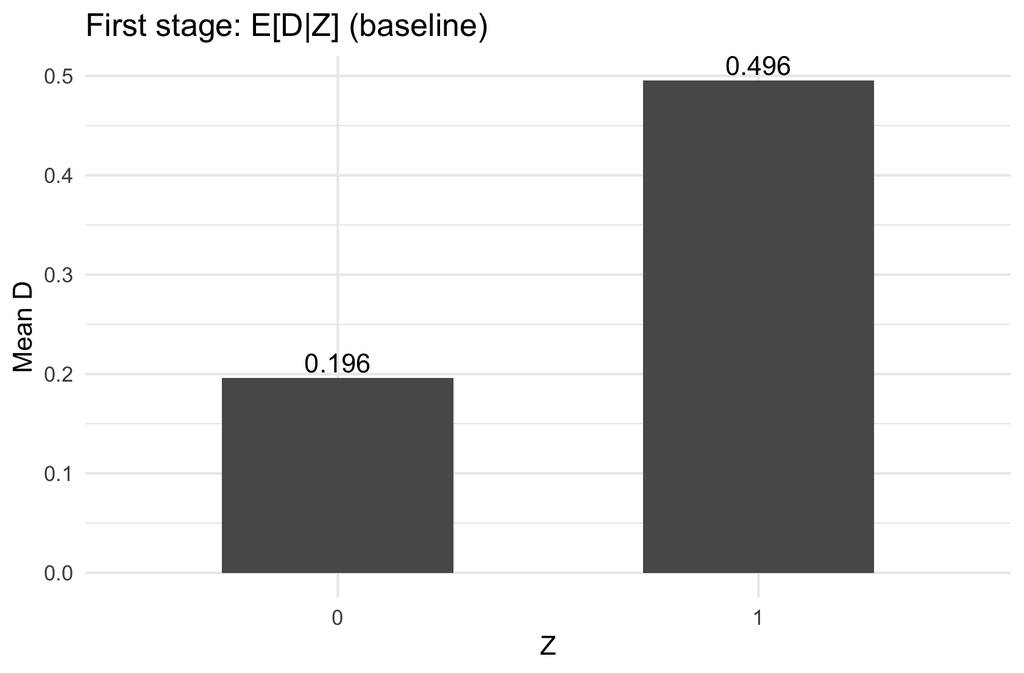

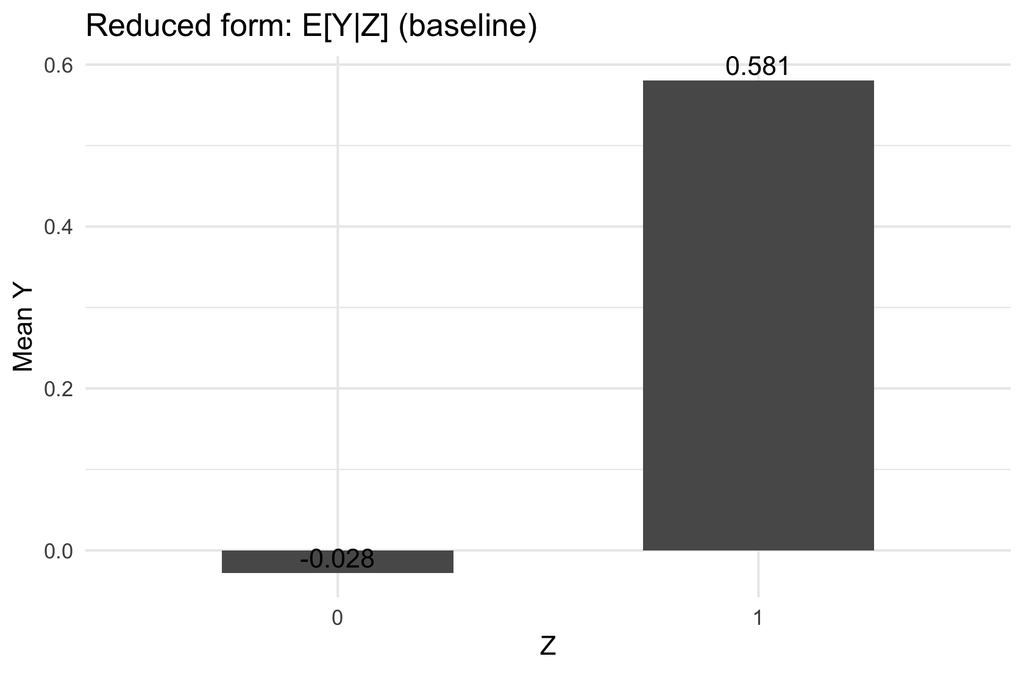

```r
plot_stage(dat0, "(baseline)")
```

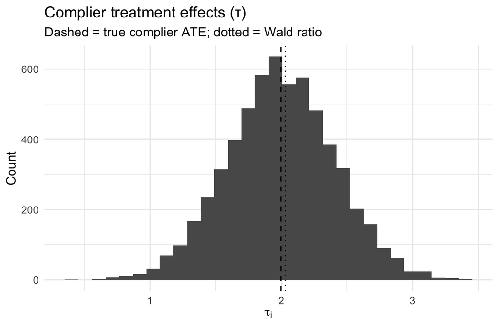

```r
plot_tau(dat0)
```

### 3.1.2 5B) Relevance violation (weak instrument)

```r
dat_rel <- simulate_late(p_c=0.02, p_d=0, exclusion=0, exog_k=0, seed=12)  # very few compliers
summarise_late(dat_rel)   # FirstStage_F falls; Wald unstable (denominator ≈ 0)
```

|  | ITT_y | ITT_d | Wald | True_Complier_ATE | IV_beta | IV_se_HC1 | FirstStage_F |
| --- | --- | --- | --- | --- | --- | --- | --- |
| D | 0.05613566 | 0.01975123 | 2.842135 | 1.985527 | 2.842135 | 1.298062 | 11.68169 |

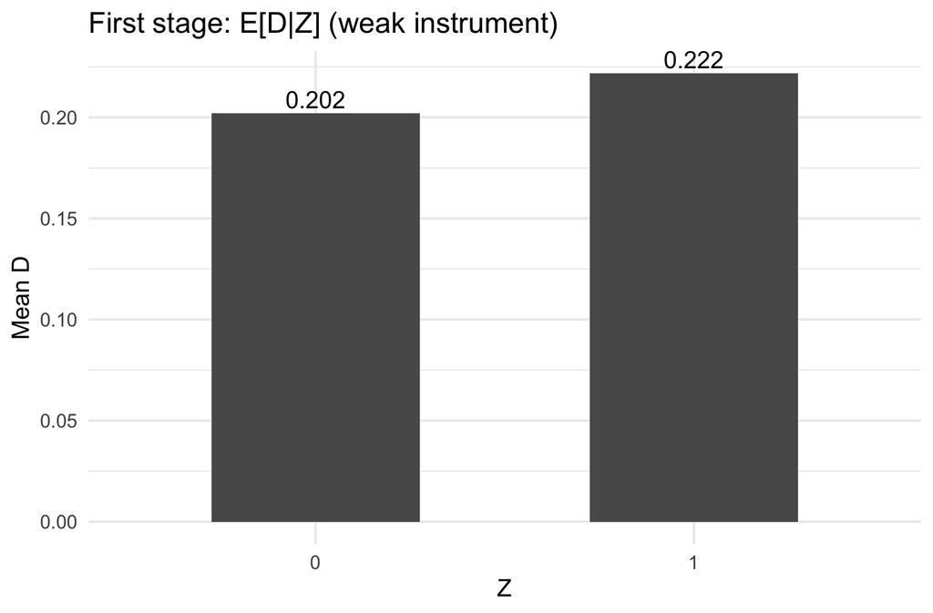

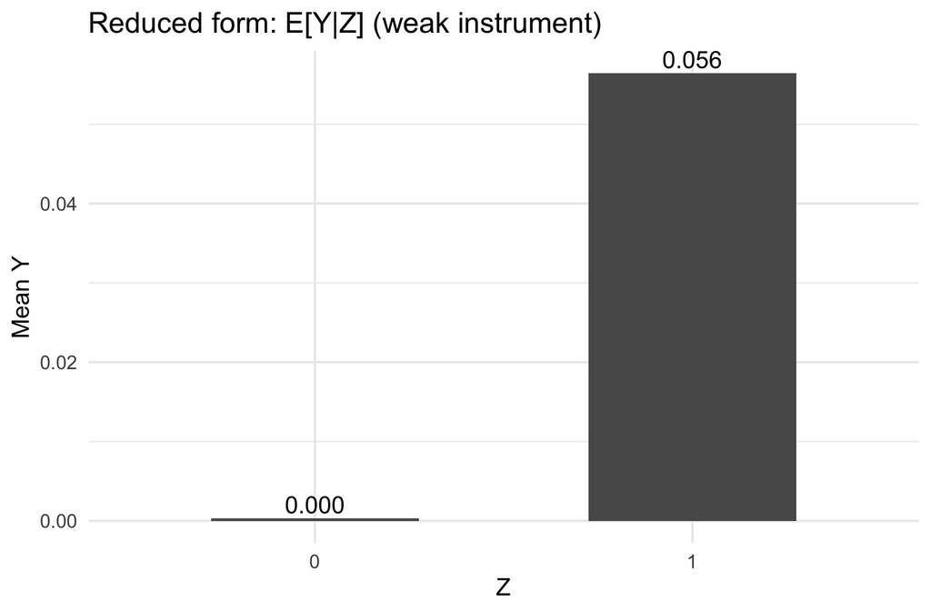

```r
plot_stage(dat_rel, "(weak instrument)")
```

### 3.1.3 5C) Exclusion violation (direct Z→Y)

```r
dat_exc <- simulate_late(p_d=0, exclusion=0.4, exog_k=0, seed=13)          # add direct channel
summarise_late(dat_exc)   # Wald/IV depart from True_Complier_ATE
```

|  | ITT_y | ITT_d | Wald | True_Complier_ATE | IV_beta | IV_se_HC1 | FirstStage_F |
| --- | --- | --- | --- | --- | --- | --- | --- |
| D | 1.019387 | 0.2988052 | 3.411545 | 2.005969 | 3.411545 | 0.09306018 | 2161.208 |

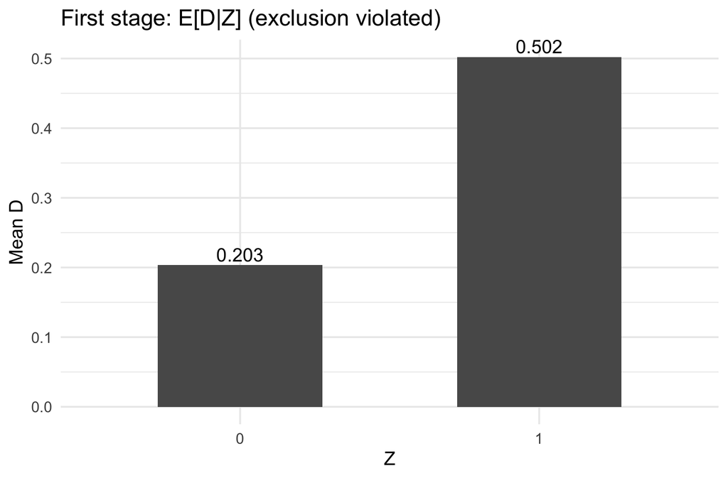

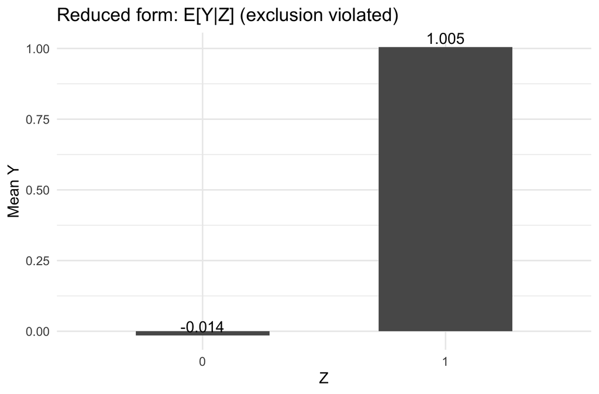

```r
plot_stage(dat_exc, "(exclusion violated)")
```

### 3.1.4 5D) Exogeneity violation (Z sorts on potential outcomes)

```r
dat_exo <- simulate_late(p_d=0, exclusion=0, exog_k=1.0, alpha_A=1.0, seed=14)  # Z depends on A
summarise_late(dat_exo)
```

|  | ITT_y | ITT_d | Wald | True_Complier_ATE | IV_beta | IV_se_HC1 | FirstStage_F |
| --- | --- | --- | --- | --- | --- | --- | --- |
| D | 1.428124 | 0.2862979 | 4.988244 | 1.99557 | 4.988244 | 0.1200921 | 1985.028 |

```r
with(dat_exo, c(E_A_Z1 = mean(A[Z==1]), E_A_Z0 = mean(A[Z==0]), diff = mean(A[Z==1]) - mean(A[Z==0])))
```

```
##     E_A_Z1     E_A_Z0       diff
##  0.4151181 -0.4153738  0.8304919
```

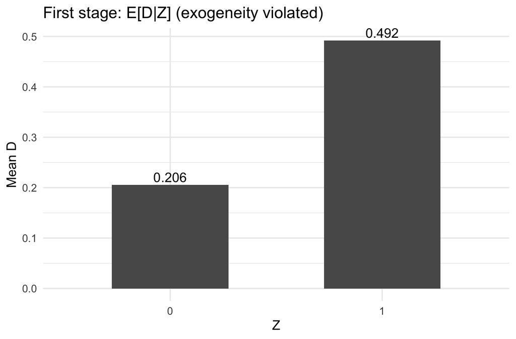

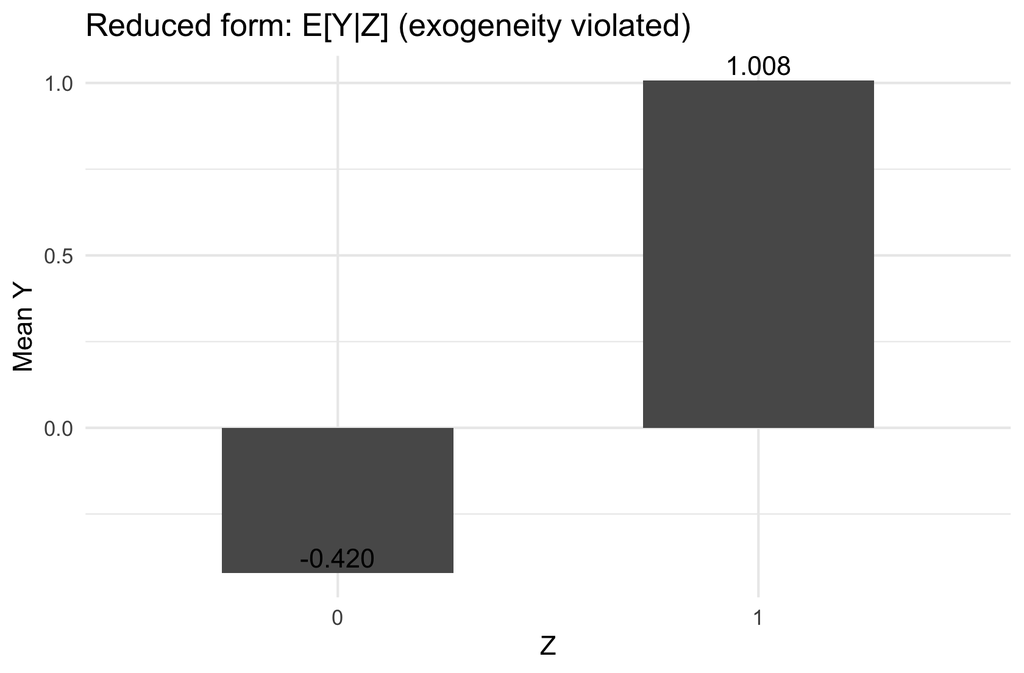

```r
plot_stage(dat_exo, "(exogeneity violated)")
```

### 3.1.5 5E) Monotonicity violation (allow defiers)

```r
dat_mon <- simulate_late(p_d=0.15, exclusion=0, exog_k=0, seed=22)         # introduce defiers
summarise_late(dat_mon)    # Wald mixes complier & defier effects; may flip sign
```

|  | ITT_y | ITT_d | Wald | True_Complier_ATE | IV_beta | IV_se_HC1 | FirstStage_F |
| --- | --- | --- | --- | --- | --- | --- | --- |
| D | 0.6190512 | 0.1522004 | 4.067342 | 2.009467 | 4.067342 | 0.2129059 | 483.458 |

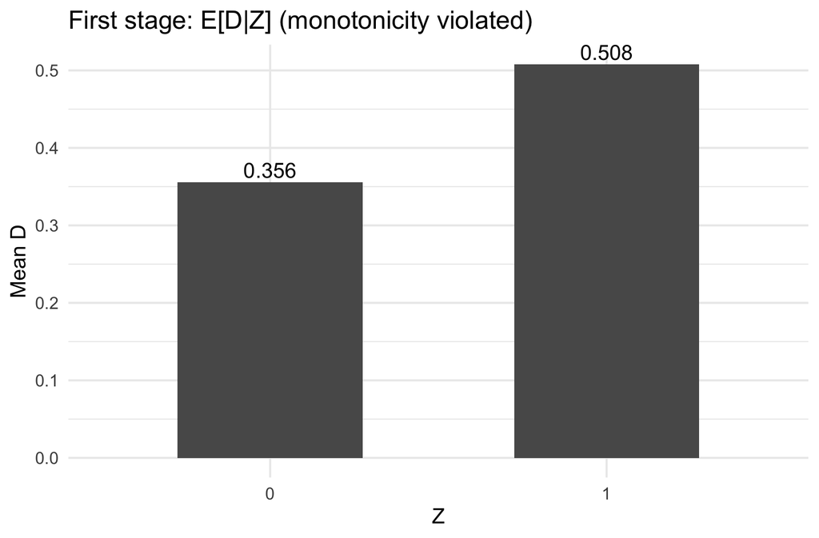

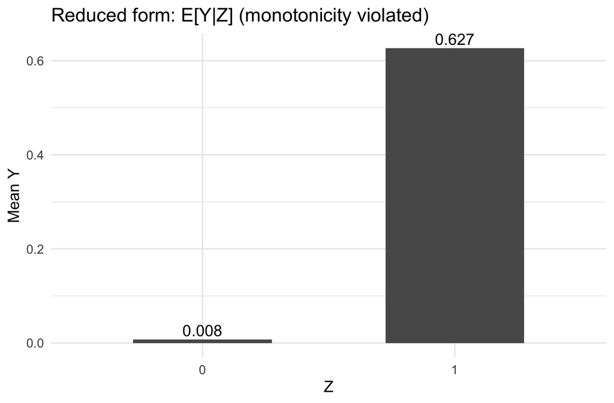

```r
plot_stage(dat_mon, "(monotonicity violated)")
```

### 3.1.6 5F) Side‑by‑side comparison table

```r
bind_rows(
  mutate(summarise_late(dat0),  Scenario="Baseline (all hold)"),
  mutate(summarise_late(dat_rel), Scenario="Relevance violated"),
  mutate(summarise_late(dat_exc), Scenario="Exclusion violated"),
  mutate(summarise_late(dat_exo), Scenario="Exogeneity violated"),
  mutate(summarise_late(dat_mon), Scenario="Monotonicity violated")
) %>%
  select(Scenario, ITT_y, ITT_d, Wald, True_Complier_ATE, IV_beta, FirstStage_F)
```

|  | Scenario | ITT_y | ITT_d | Wald | True_Complier_ATE | IV_beta | FirstStage_F |
| --- | --- | --- | --- | --- | --- | --- | --- |
| D...1 | Baseline (all hold) | 0.60822794 | 0.29971411 | 2.029360 | 1.995906 | 2.029360 | 2200.37391 |
| D...2 | Relevance violated | 0.05613566 | 0.01975123 | 2.842135 | 1.985527 | 2.842135 | 11.68169 |
| D...3 | Exclusion violated | 1.01938736 | 0.29880521 | 3.411545 | 2.005969 | 3.411545 | 2161.20815 |
| D...4 | Exogeneity violated | 1.42812371 | 0.28629790 | 4.988244 | 1.995570 | 4.988244 | 1985.02806 |
| D...5 | Monotonicity violated | 0.61905121 | 0.15220044 | 4.067342 | 2.009467 | 4.067342 | 483.45804 |

## 3.2 Closing Remarks

- **From ratios to matrices:** In just‑ID settings, IV equals the **reduced‑form slope ratio** $\hat\beta = \hat\gamma/\hat\alpha$. In over‑ID cases, TSLS equals $(X'P_ZX)^{-1}X'P_ZY$ (slides Eqs. 8–11).
- **When is IV a causal effect?** Under **relevance, exogeneity, exclusion, and monotonicity**, the IV coefficient with binary $Z,D$ equals **LATE** (slides pp. 23–27).
- **What breaks what?** Weak instruments ⇒ instability; exclusion or exogeneity failures ⇒ **bias**; monotonicity failure (defiers) ⇒ **not** a complier ATE (ratio mixes strata). (Slides pp. 31–38.)